# homework-07

Brian J Lesko

2022-05-30

```r
library(ggplot2) # or library(tidyverse)
library(tidyverse)
library(nycflights13)
```

# Reading

Read R4DS 12.1–12.3 and R4DS 13.1–13.5

# R4DS Exercises

## 12.2.1 (1–3)

### Exercise 1

Using prose, describe how the variables and observations are organised in each of the sample tables.

Table 1: Table one is tidy, meaning that each variable has its own column and each observation has its own row. As a consequence, his results in each value having its own cell.

Table 2: Each observation in time has two rows in this dataset, each row has the country and time, but for the same observation in time, one row will have a variable called type of the character string of the value “cases” or “population”. the count variable then describes the count of either the cases or population depending on the type variable,

Table 3: In this dataset, each observation in time has only one row. The country and year exist in columns along with a rate variable that describes the cases / population in one cell. In this aspect it can be thought that there is only one composite varaible, or that two variables are in a single cell.

Table 4: In table 4, two tibbles are used. One describes the number of cases while the other describes the population, with every year with its own column.

### Exercise 2

Compute the rate for table2 and table4a + table4b. Four operations are necessary: extract the # of TB cases per country per year extract the matching population per country per year divide the cases by population, and multiply by 10,000 store back in the appropriate place

Which representation is easiest? why? Which is hardest, and why?

Table 4 was more difficult because of its two table layout, figuring out how to combine the data and select it was most difficult. Table 2 was easy to convert to a tidy layout which then made computing the rate very easy.

```r
table2
```

```
## # A tibble: 12 × 4
##    country      year type            count
##    <chr>       <int> <chr>           <int>
##  1 Afghanistan  1999 cases             745
##  2 Afghanistan  1999 population   19987071
##  3 Afghanistan  2000 cases            2666
##  4 Afghanistan  2000 population   20595360
##  5 Brazil       1999 cases           37737
##  6 Brazil       1999 population  172006362
##  7 Brazil       2000 cases           80488
##  8 Brazil       2000 population  174504898
##  9 China        1999 cases          212258
## 10 China        1999 population 1272915272
## 11 China        2000 cases          213766
## 12 China        2000 population 1280428583
```

```r
table2M <- table2 %>%
  pivot_wider(names_from=type,values_from=count) %>%
  mutate(rate=cases/population*10000)

table2M
```

```
## # A tibble: 6 × 5
##   country      year  cases population  rate
##   <chr>       <int>  <int>      <int> <dbl>
## 1 Afghanistan  1999    745   19987071 0.373
## 2 Afghanistan  2000   2666   20595360 1.29
## 3 Brazil       1999  37737  172006362 2.19
## 4 Brazil       2000  80488  174504898 4.61
## 5 China        1999 212258 1272915272 1.67
## 6 China        2000 213766 1280428583 1.67
```

```r
#is this what is asked for? I made the table tidy, then computed the rate??
# the data is stored better now

table4Rate <-tibble(
  country = table4a$country,
  `1999`=table4a[["1999"]]/table4b[["1999"]]*10000, #refrence creating improper variable names
  `2000`=table4a[["2000"]]/table4b[["2000"]]*10000
)

table4Rate
```

```
## # A tibble: 3 × 3
##   country     `1999` `2000`
##   <chr>        <dbl>  <dbl>
## 1 Afghanistan  0.373   1.29
## 2 Brazil       2.19    4.61
## 3 China        1.67    1.67
```

```r
#trying table 2 again for the fun of it. this time keeping the style of the original table

table2cases <- table2 %>%
  filter(type=="cases")

table2population <- table2 %>%
  filter(type=="population")

table2Rate <- tibble(
  rate = table2cases[["count"]]/table2population[["count"]]*10000
)
table2Rate #this attempt is a fail
```

```
## # A tibble: 6 × 1
##    rate
##   <dbl>
## 1 0.373
## 2 1.29
## 3 2.19
## 4 4.61
## 5 1.67
## 6 1.67
```

### Exercise 3

Recreate the plot showing change in cases over time using table2 instead of table1. What do you need to do first?

The first thing I did was filter the data so that only the cases rows would remain

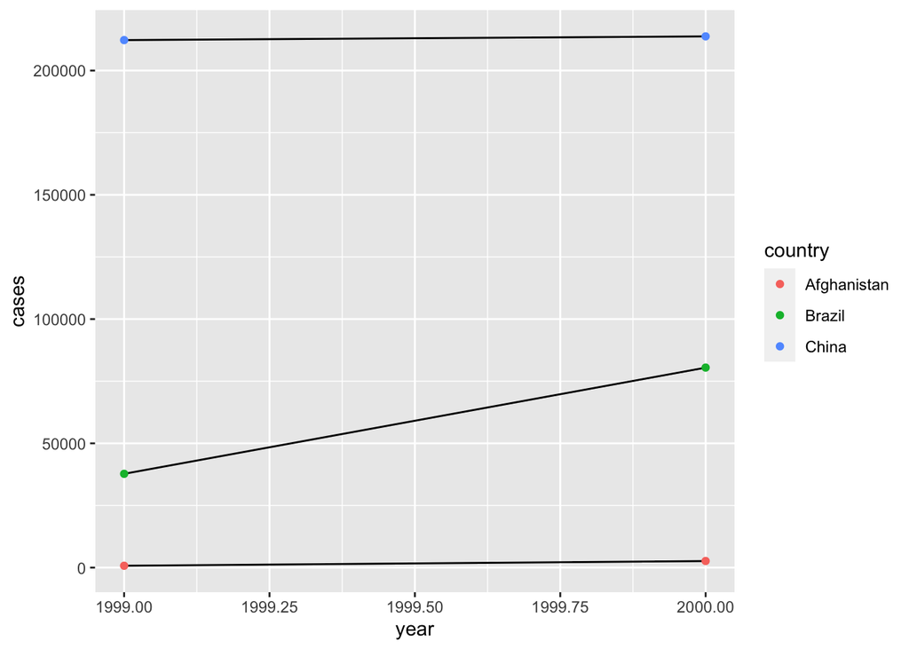

```r
table2 %>%
  filter(type=="cases") %>%
  ggplot(aes(x=year,y=count)) +
  geom_line(aes(group=country),color="black") +
  geom_point(aes(color=country)) +
  labs(y="cases")
```

## 12.3.3 (1–4)

### Exercise 1

Why are the pivot functions not symmetrical?

```r
stocks <- tibble(
  year   = c(2015, 2015, 2016, 2016),
  half  = c(   1,    2,     1,    2),
  return = c(1.88, 0.59, 0.92, 0.17)
)
stocks
```

```
## # A tibble: 4 × 3
##    year  half return
##   <dbl> <dbl>  <dbl>
## 1  2015     1   1.88
## 2  2015     2   0.59
## 3  2016     1   0.92
## 4  2016     2   0.17
```

```r
stocks %>%
  pivot_wider(names_from = year, values_from = return) %>%
  pivot_longer(`2015`:`2016`, names_to = "year", values_to = "return")
```

```
## # A tibble: 4 × 3
##    half year  return
##   <dbl> <chr>  <dbl>
## 1     1 2015    1.88
## 2     1 2016    0.92
## 3     2 2015    0.59
## 4     2 2016    0.17
```

it can be seen that the operations are not perfectly symmetrical because the order of boht columns and rows is not preserved after the useage of wider and longer functions. This can be visualised with the help of table 12.3:pivoting into a “wider”, tidy form and table 12.2: Pivoting table4 into a longer, tidy form

the column variable types are also not preserved, they start as all doubles, but afterward, the year becomes a character.

names_ptypes confirms that the new column variables have the expected types/attributes/class, it is a list so that each column can be confirmed seperately.

### Exercise 2

Why does this code fail?

```r
table4a %>%
  pivot_longer(c(`1999`, `2000`), names_to = "year", values_to = "cases")
```

```
## # A tibble: 6 × 3
##   country     year   cases
##   <chr>       <chr>  <int>
## 1 Afghanistan 1999     745
## 2 Afghanistan 2000    2666
## 3 Brazil      1999   37737
## 4 Brazil      2000   80488
## 5 China       1999  212258
## 6 China       2000  213766
```

```
#> Error: Can't subset columns that don't exist.
#> ✖ Locations 1999 and 2000 don't exist.
#> ℹ There are only 3 columns.
```

The code needed backticks around the concatonated years in order to distinguish them from improper variable names. I fixed this and the code works.

### Exercise 3

what would haoppen if you widen this table? why? how could you add a new column to uniquely identify each value?

The wider operation will not work as intended because the name and names columns are repeatable, there are two rows with age for phillip woods, this does not allow creating columns from the values in the names column.

If another column is added using a group by name and names followed by a mutate using row number, this new variable can then uniquely identify each value along with the name column. Then pivot wider will work as intended.

```r
people <- tribble(
  ~name,             ~names,  ~values,
  #-----------------|--------|------
  "Phillip Woods",   "age",       45,
  "Phillip Woods",   "height",   186,
  "Phillip Woods",   "age",       50,
  "Jessica Cordero", "age",       37,
  "Jessica Cordero", "height",   156
)
people
```

```
## # A tibble: 5 × 3
##   name            names  values
##   <chr>           <chr>   <dbl>
## 1 Phillip Woods   age        45
## 2 Phillip Woods   height    186
## 3 Phillip Woods   age        50
## 4 Jessica Cordero age        37
## 5 Jessica Cordero height    156
```

```r
people_wider <- people %>%
  pivot_wider(names_from=names,values_from=values)
people_wider
```

```
## # A tibble: 2 × 3
##   name            age       height
##   <chr>           <list>    <list>
## 1 Phillip Woods   <dbl [2]> <dbl [1]>
## 2 Jessica Cordero <dbl [1]> <dbl [1]>
```

### Exercise 4

Tidy the table below. is wider or longer needed? What are the variables

```r
preg <- tribble(
  ~pregnant, ~male, ~female,
  "yes",     NA,    10,
  "no",      20,    12
)
preg
```

```
## # A tibble: 2 × 3
##   pregnant  male female
##   <chr>    <dbl>  <dbl>
## 1 yes         NA     10
## 2 no          20     12
```

```r
#the variables should be
#person number(int), gender(chr), pregnant(chr)
#Correction below
#gender(chr), pregnant(chr), number(int)
#this second way is the preffered method

preg_tidy <- preg %>%
  pivot_longer(cols=c(male,female),names_to="gender",values_to="number")

preg_tidy
```

```
## # A tibble: 4 × 3
##   pregnant gender number
##   <chr>    <chr>   <dbl>
## 1 yes      male       NA
## 2 yes      female     10
## 3 no       male       20
## 4 no       female     12
```

## 13.3.1 (1–2)

### Exercise 1

Add a surrogate key to flights

```r
flightsS <- flights %>%
  mutate(key=row_number()) %>%
  select(key,everything())

flightsS
```

```
## # A tibble: 336,776 × 20
##      key  year month   day dep_time sched_dep_time dep_delay arr_time
##    <int> <int> <int> <int>    <int>          <int>     <dbl>    <int>
##  1     1  2013     1     1      517            515         2      830
##  2     2  2013     1     1      533            529         4      850
##  3     3  2013     1     1      542            540         2      923
##  4     4  2013     1     1      544            545        -1     1004
##  5     5  2013     1     1      554            600        -6      812
##  6     6  2013     1     1      554            558        -4      740
##  7     7  2013     1     1      555            600        -5      913
##  8     8  2013     1     1      557            600        -3      709
##  9     9  2013     1     1      557            600        -3      838
## 10    10  2013     1     1      558            600        -2      753
## # … with 336,766 more rows, and 12 more variables: sched_arr_time <int>,
## #   arr_delay <dbl>, carrier <chr>, flight <int>, tailnum <chr>, origin <chr>,
## #   dest <chr>, air_time <dbl>, distance <dbl>, hour <dbl>, minute <dbl>,
## #   time_hour <dttm>
```

### Exercise 2

Identify the Keys in the following datasets

```r
#install.packages("Lahman")
library(Lahman)
```

```r
Lahman::Batting
```

```
##       playerID yearID stint teamID lgID   G  AB   R   H X2B X3B HR RBI  SB CS
## 1    abercda01   1871     1    TRO   NA   1   4   0   0   0   0  0   0   0  0
## 2     addybo01   1871     1    RC1   NA  25 118  30  32   6   0  0  13   8  1
## 3    allisar01   1871     1    CL1   NA  29 137  28  40   4   5  0  19   3  1
## 4    allisdo01   1871     1    WS3   NA  27 133  28  44  10   2  2  27   1  1
## 5    ansonca01   1871     1    RC1   NA  25 120  29  39  11   3  0  16   6  2
## 6    armstbo01   1871     1    FW1   NA  12  49   9  11   2   1  0   5   0  1
## 7    barkeal01   1871     1    RC1   NA   1   4   0   1   0   0  0   2   0  0
## 8    barnero01   1871     1    BS1   NA  31 157  66  63  10   9  0  34  11  6
## 9    barrebi01   1871     1    FW1   NA   1   5   1   1   1   0  0   1   0  0
## 10   barrofr01   1871     1    BS1   NA  18  86  13  13   2   1  0  11   1  0
## 11    bassjo01   1871     1    CL1   NA  22  89  18  27   1  10  3  18   0  1
## 12   battijo01   1871     1    CL1   NA   1   3   0   0   0   0  0   0   0  0
## 13   bealsto01   1871     1    WS3   NA  10  36   6   7   0   0  0   1   2  0
## 14   beaveed01   1871     1    TRO   NA   3  15   7   6   0   0  0   5   2  0
```

[output cut: 9078 more lines]

```r
Lahman::Batting %>%
  count(playerID,yearID,teamID,stint) %>%
  filter(n > 1)
```

```
## [1] playerID yearID   teamID   stint    n
## <0 rows> (or 0-length row.names)
```

```r
#since stint is the order of appearances, it may allow the exclusion of TeamID in the dataset key
Lahman::Batting %>%
  count(playerID,yearID,stint) %>%
  filter(n > 1)
```

```
## [1] playerID yearID   stint    n
## <0 rows> (or 0-length row.names)
```

```r
#this turns out to be true
```

```r
#install.packages("babynames")
library(babynames)
```

```r
babynames::babynames
```

```
## # A tibble: 1,924,665 × 5
##     year sex   name          n   prop
##    <dbl> <chr> <chr>     <int>  <dbl>
##  1  1880 F     Mary       7065 0.0724
##  2  1880 F     Anna       2604 0.0267
##  3  1880 F     Emma       2003 0.0205
##  4  1880 F     Elizabeth  1939 0.0199
##  5  1880 F     Minnie     1746 0.0179
##  6  1880 F     Margaret   1578 0.0162
##  7  1880 F     Ida        1472 0.0151
##  8  1880 F     Alice      1414 0.0145
##  9  1880 F     Bertha     1320 0.0135
## 10  1880 F     Sarah      1288 0.0132
## # … with 1,924,655 more rows
```

```r
babynames %>%
  count(year,sex,name) %>%
  filter(n>1)
```

```
## # A tibble: 0 × 4
## # … with 4 variables: year <dbl>, sex <chr>, name <chr>, n <int>
```

```r
#year sex and name work as a key here

babynames %>%
  filter(prop==max(prop))
```

```
## # A tibble: 1 × 5
##    year sex   name      n   prop
##   <dbl> <chr> <chr> <int>  <dbl>
## 1  1880 M     John   9655 0.0815
```

```r
#install.packages("nasaweather")
library(nasaweather)
```

```r
nasaweather::atmos
```

```
## # A tibble: 41,472 × 11
##      lat  long  year month surftemp  temp pressure ozone cloudlow cloudmid
##    <dbl> <dbl> <int> <int>    <dbl> <dbl>    <dbl> <dbl>    <dbl>    <dbl>
##  1  36.2 -114.  1995     1     273.  272.      835   304      7.5     34.5
##  2  33.7 -114.  1995     1     280.  282.      940   304     11.5     32.5
##  3  31.2 -114.  1995     1     285.  285.      960   298     16.5     26
##  4  28.7 -114.  1995     1     289.  291.      990   276     20.5     14.5
##  5  26.2 -114.  1995     1     292.  293.     1000   274     26       10.5
##  6  23.7 -114.  1995     1     294.  294.     1000   264     30        9.5
##  7  21.2 -114.  1995     1     295   295.     1000   258     29.5     11
##  8  18.7 -114.  1995     1     298.  297.     1000   252     26.5     17.5
##  9  16.2 -114.  1995     1     300.  298.     1000   250     27.5     18.5
## 10  13.7 -114.  1995     1     300.  299.     1000   250     26       16.5
## # … with 41,462 more rows, and 1 more variable: cloudhigh <dbl>
```

```r
atmos %>%
  count(year,month,lat,long) %>%
  filter(n>1)
```

```
## # A tibble: 0 × 5
## # … with 5 variables: year <int>, month <int>, lat <dbl>, long <dbl>, n <int>
```

```r
#year month lat and long work as a key
```

```r
#install.packages("fueleconomy")
library(fueleconomy)
```

```r
fueleconomy::vehicles
```

```
## # A tibble: 33,442 × 12
##       id make  model        year class trans drive   cyl displ fuel    hwy   cty
##    <dbl> <chr> <chr>       <dbl> <chr> <chr> <chr> <dbl> <dbl> <chr> <dbl> <dbl>
##  1 13309 Acura 2.2CL/3.0CL  1997 Subc… Auto… Fron…     4   2.2 Regu…    26    20
##  2 13310 Acura 2.2CL/3.0CL  1997 Subc… Manu… Fron…     4   2.2 Regu…    28    22
##  3 13311 Acura 2.2CL/3.0CL  1997 Subc… Auto… Fron…     6   3   Regu…    26    18
##  4 14038 Acura 2.3CL/3.0CL  1998 Subc… Auto… Fron…     4   2.3 Regu…    27    19
##  5 14039 Acura 2.3CL/3.0CL  1998 Subc… Manu… Fron…     4   2.3 Regu…    29    21
##  6 14040 Acura 2.3CL/3.0CL  1998 Subc… Auto… Fron…     6   3   Regu…    26    17
##  7 14834 Acura 2.3CL/3.0CL  1999 Subc… Auto… Fron…     4   2.3 Regu…    27    20
##  8 14835 Acura 2.3CL/3.0CL  1999 Subc… Manu… Fron…     4   2.3 Regu…    29    21
##  9 14836 Acura 2.3CL/3.0CL  1999 Subc… Auto… Fron…     6   3   Regu…    26    17
## 10 11789 Acura 2.5TL        1995 Comp… Auto… Fron…     5   2.5 Prem…    23    18
## # … with 33,432 more rows
```

```r
vehicles %>%
  count(id) %>%
  filter(n>1)
```

```
## # A tibble: 0 × 2
## # … with 2 variables: id <dbl>, n <int>
```

```r
#Id is enough in this case
```

```r
diamonds
```

```
## # A tibble: 53,940 × 10
##    carat cut       color clarity depth table price     x     y     z
##    <dbl> <ord>     <ord> <ord>   <dbl> <dbl> <int> <dbl> <dbl> <dbl>
##  1  0.23 Ideal     E     SI2      61.5    55   326  3.95  3.98  2.43
##  2  0.21 Premium   E     SI1      59.8    61   326  3.89  3.84  2.31
##  3  0.23 Good      E     VS1      56.9    65   327  4.05  4.07  2.31
##  4  0.29 Premium   I     VS2      62.4    58   334  4.2   4.23  2.63
##  5  0.31 Good      J     SI2      63.3    58   335  4.34  4.35  2.75
##  6  0.24 Very Good J     VVS2     62.8    57   336  3.94  3.96  2.48
##  7  0.24 Very Good I     VVS1     62.3    57   336  3.95  3.98  2.47
##  8  0.26 Very Good H     SI1      61.9    55   337  4.07  4.11  2.53
##  9  0.22 Fair      E     VS2      65.1    61   337  3.87  3.78  2.49
## 10  0.23 Very Good H     VS1      59.4    61   338  4     4.05  2.39
## # … with 53,930 more rows
```

```r
diamonds %>%
  count(carat,cut,color,clarity,depth,table,price,x,y,z) %>%
  filter(n>1)
```

```
## # A tibble: 143 × 11
##    carat cut       color clarity depth table price     x     y     z     n
##    <dbl> <ord>     <ord> <ord>   <dbl> <dbl> <int> <dbl> <dbl> <dbl> <int>
##  1  0.3  Good      J     VS1      63.4    57   394  4.23  4.26  2.69     2
##  2  0.3  Very Good G     VS2      63      55   526  4.29  4.31  2.71     2
##  3  0.3  Very Good J     VS1      63.4    57   506  4.26  4.23  2.69     2
##  4  0.3  Premium   D     SI1      62.2    58   709  4.31  4.28  2.67     2
##  5  0.3  Ideal     G     VS2      63      55   675  4.31  4.29  2.71     2
##  6  0.3  Ideal     G     IF       62.1    55   863  4.32  4.35  2.69     2
##  7  0.3  Ideal     H     SI1      62.2    57   450  4.26  4.29  2.66     2
##  8  0.3  Ideal     H     SI1      62.2    57   450  4.27  4.28  2.66     2
##  9  0.31 Good      D     SI1      63.5    56   571  4.29  4.31  2.73     2
## 10  0.31 Very Good D     SI1      63.5    56   732  4.31  4.29  2.73     2
## # … with 133 more rows
```

```r
#No variable combination will work as a key (I tried every variable in the check), a surrogate key may be useful.
```

## 13.4.6 (1–5)

### Exercise 1

Compute the average delay by destination, then join on the airports data frame so you can show the spatial distribution of delays. Here’s an easy way to draw a map of the United States:

```r
delay_by_dest <- flights %>%
  group_by(dest) %>%
  summarise(avg_delay=mean(arr_delay,na.rm=T))

delay_by_dest
```

```
## # A tibble: 105 × 2
##    dest  avg_delay
##    <chr>     <dbl>
##  1 ABQ        4.38
##  2 ACK        4.85
##  3 ALB       14.4
##  4 ANC       -2.5
##  5 ATL       11.3
##  6 AUS        6.02
##  7 AVL        8.00
##  8 BDL        7.05
##  9 BGR        8.03
## 10 BHM       16.9
## # … with 95 more rows
```

```r
joined <- delay_by_dest %>%
  left_join(airports,c("dest"="faa"))

joined
```

```
## # A tibble: 105 × 9
##    dest  avg_delay name                       lat    lon   alt    tz dst   tzone
##    <chr>     <dbl> <chr>                    <dbl>  <dbl> <dbl> <dbl> <chr> <chr>
##  1 ABQ        4.38 Albuquerque Internation…  35.0 -107.   5355    -7 A     Amer…
##  2 ACK        4.85 Nantucket Mem             41.3  -70.1    48    -5 A     Amer…
##  3 ALB       14.4  Albany Intl               42.7  -73.8   285    -5 A     Amer…
##  4 ANC       -2.5  Ted Stevens Anchorage I…  61.2 -150.    152    -9 A     Amer…
##  5 ATL       11.3  Hartsfield Jackson Atla…  33.6  -84.4  1026    -5 A     Amer…
##  6 AUS        6.02 Austin Bergstrom Intl     30.2  -97.7   542    -6 A     Amer…
##  7 AVL        8.00 Asheville Regional Airp…  35.4  -82.5  2165    -5 A     Amer…
##  8 BDL        7.05 Bradley Intl              41.9  -72.7   173    -5 A     Amer…
##  9 BGR        8.03 Bangor Intl               44.8  -68.8   192    -5 A     Amer…
## 10 BHM       16.9  Birmingham Intl           33.6  -86.8   644    -6 A     Amer…
## # … with 95 more rows
```

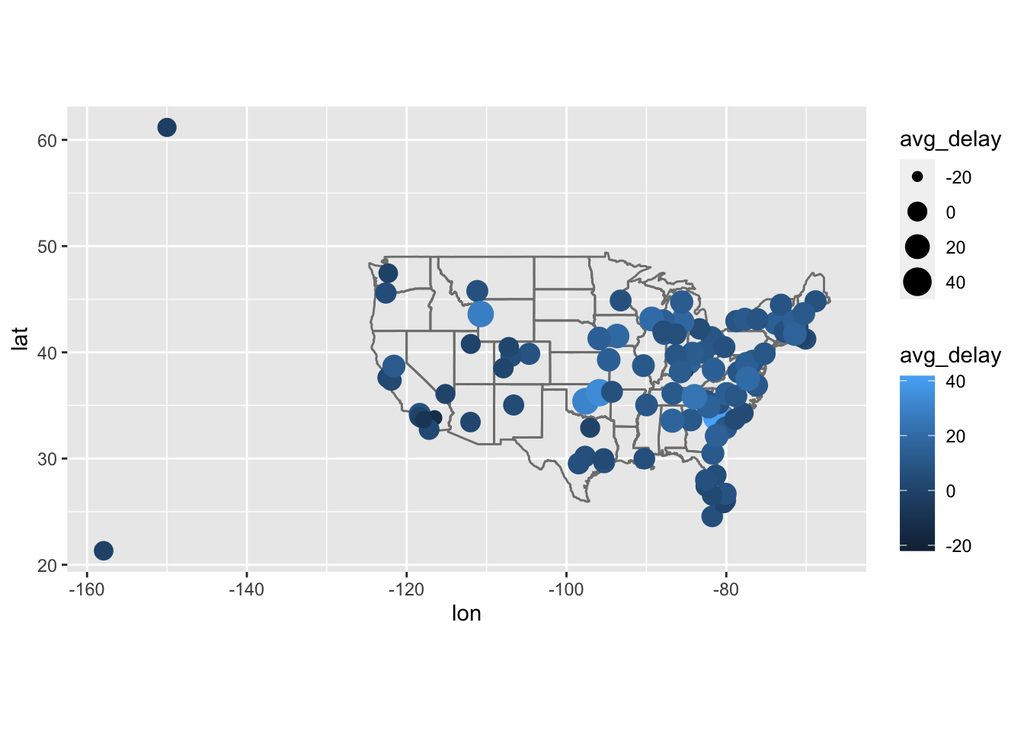

```r
joined %>%
  ggplot(aes(lon, lat,color=avg_delay,size=avg_delay)) +
    borders("state") +
    geom_point() +
    coord_quickmap()
```

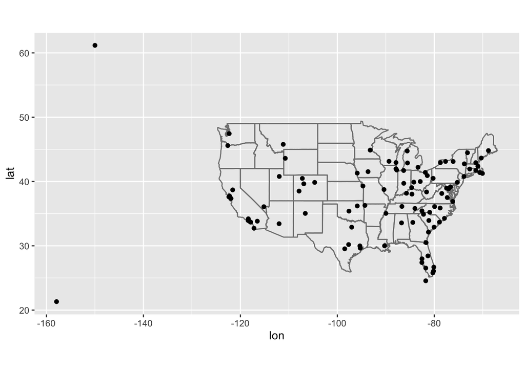

```r
#the given code for refrence
airports %>%
  semi_join(flights, c("faa" = "dest")) %>%
  ggplot(aes(lon, lat)) +
    borders("state") +
    geom_point() +
    coord_quickmap()
```

### Exercise 2

Add the location of the origin and destination (i.e. the lat and lon) to flights

```r
flights2 <- flights %>%
  left_join(airports,by=c("dest"="faa")) %>%
  rename(dest_lat=lat) %>%
  rename(dest_lon=lon) %>%
  left_join(airports,by=c("origin"="faa")) %>%
  rename(origin_lat=lat,origin_lon=lon)

flights2
```

```
## # A tibble: 336,776 × 33
##     year month   day dep_time sched_dep_time dep_delay arr_time sched_arr_time
##    <int> <int> <int>    <int>          <int>     <dbl>    <int>          <int>
##  1  2013     1     1      517            515         2      830            819
##  2  2013     1     1      533            529         4      850            830
##  3  2013     1     1      542            540         2      923            850
##  4  2013     1     1      544            545        -1     1004           1022
##  5  2013     1     1      554            600        -6      812            837
##  6  2013     1     1      554            558        -4      740            728
##  7  2013     1     1      555            600        -5      913            854
##  8  2013     1     1      557            600        -3      709            723
##  9  2013     1     1      557            600        -3      838            846
## 10  2013     1     1      558            600        -2      753            745
## # … with 336,766 more rows, and 25 more variables: arr_delay <dbl>,
## #   carrier <chr>, flight <int>, tailnum <chr>, origin <chr>, dest <chr>,
## #   air_time <dbl>, distance <dbl>, hour <dbl>, minute <dbl>, time_hour <dttm>,
## #   name.x <chr>, dest_lat <dbl>, dest_lon <dbl>, alt.x <dbl>, tz.x <dbl>,
## #   dst.x <chr>, tzone.x <chr>, name.y <chr>, origin_lat <dbl>,
## #   origin_lon <dbl>, alt.y <dbl>, tz.y <dbl>, dst.y <chr>, tzone.y <chr>
```

### Exercise 3

Is there a relationship between plane age and its delays?

There seems not to be any relationship between plane age and delay. This is somewhat unexpected.

```r
delay_by_plane <- flights %>%
  group_by(tailnum) %>%
  summarise(delay=mean(arr_delay,na.rm=T))

delay_by_plane
```

```
## # A tibble: 4,044 × 2
##    tailnum  delay
##    <chr>    <dbl>
##  1 D942DN  31.5
##  2 N0EGMQ   9.98
##  3 N10156  12.7
##  4 N102UW   2.94
##  5 N103US  -6.93
##  6 N104UW   1.80
##  7 N10575  20.7
##  8 N105UW  -0.267
##  9 N107US  -5.73
## 10 N108UW  -1.25
## # … with 4,034 more rows
```

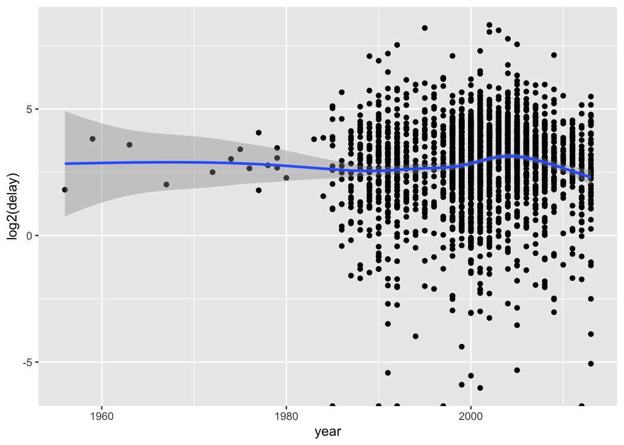

```r
delay_by_plane %>%
  left_join(planes) %>%
  ggplot(mapping=aes(year,log2(delay))) +
  geom_point() +
  geom_smooth()
```

### Exercise 4

What weather conditions make delay more likely?

```r
rain_delay <- flights %>%
  left_join(weather,by =c("origin" = "origin",
                            "year" = "year",
                          "month" = "month",
                          "day" = "day",
                          "hour" = "hour")
             ) %>%
  group_by(precip) %>%
  mutate(delay=mean(arr_delay,na.rm =T))

rain_delay
```

```
## # A tibble: 336,776 × 30
## # Groups:   precip [56]
##     year month   day dep_time sched_dep_time dep_delay arr_time sched_arr_time
##    <int> <int> <int>    <int>          <int>     <dbl>    <int>          <int>
##  1  2013     1     1      517            515         2      830            819
##  2  2013     1     1      533            529         4      850            830
##  3  2013     1     1      542            540         2      923            850
##  4  2013     1     1      544            545        -1     1004           1022
##  5  2013     1     1      554            600        -6      812            837
##  6  2013     1     1      554            558        -4      740            728
##  7  2013     1     1      555            600        -5      913            854
##  8  2013     1     1      557            600        -3      709            723
##  9  2013     1     1      557            600        -3      838            846
## 10  2013     1     1      558            600        -2      753            745
## # … with 336,766 more rows, and 22 more variables: arr_delay <dbl>,
## #   carrier <chr>, flight <int>, tailnum <chr>, origin <chr>, dest <chr>,
## #   air_time <dbl>, distance <dbl>, hour <dbl>, minute <dbl>,
## #   time_hour.x <dttm>, temp <dbl>, dewp <dbl>, humid <dbl>, wind_dir <dbl>,
## #   wind_speed <dbl>, wind_gust <dbl>, precip <dbl>, pressure <dbl>,
## #   visib <dbl>, time_hour.y <dttm>, delay <dbl>
```

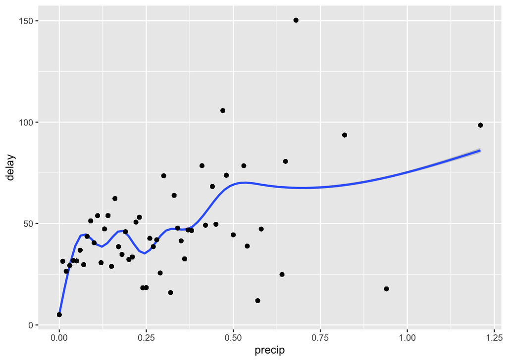

```r
  ggplot(data=rain_delay) +
    geom_smooth(mapping=aes(x=precip,y=delay)) +
    geom_point(mapping=aes(x=precip,y=delay))
```

Delay increases as precipitation increases

```r
visib_delay <- flights %>%
  left_join(weather,by =c("origin" = "origin",
                            "year" = "year",
                          "month" = "month",
                          "day" = "day",
                          "hour" = "hour")
             ) %>%
  group_by(visib) %>%
  mutate(delay=mean(arr_delay,na.rm =T))

visib_delay
```

```
## # A tibble: 336,776 × 30
## # Groups:   visib [21]
##     year month   day dep_time sched_dep_time dep_delay arr_time sched_arr_time
##    <int> <int> <int>    <int>          <int>     <dbl>    <int>          <int>
##  1  2013     1     1      517            515         2      830            819
##  2  2013     1     1      533            529         4      850            830
##  3  2013     1     1      542            540         2      923            850
##  4  2013     1     1      544            545        -1     1004           1022
##  5  2013     1     1      554            600        -6      812            837
##  6  2013     1     1      554            558        -4      740            728
##  7  2013     1     1      555            600        -5      913            854
##  8  2013     1     1      557            600        -3      709            723
##  9  2013     1     1      557            600        -3      838            846
## 10  2013     1     1      558            600        -2      753            745
## # … with 336,766 more rows, and 22 more variables: arr_delay <dbl>,
## #   carrier <chr>, flight <int>, tailnum <chr>, origin <chr>, dest <chr>,
## #   air_time <dbl>, distance <dbl>, hour <dbl>, minute <dbl>,
## #   time_hour.x <dttm>, temp <dbl>, dewp <dbl>, humid <dbl>, wind_dir <dbl>,
## #   wind_speed <dbl>, wind_gust <dbl>, precip <dbl>, pressure <dbl>,
## #   visib <dbl>, time_hour.y <dttm>, delay <dbl>
```

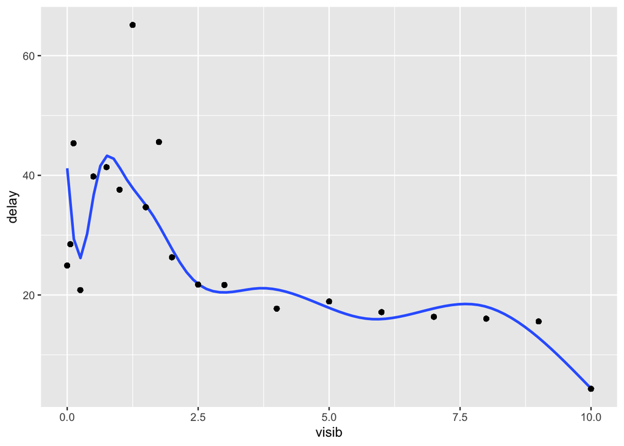

```r
  ggplot(data=visib_delay) +
    geom_smooth(mapping=aes(x=visib,y=delay)) +
    geom_point(mapping=aes(x=visib,y=delay))
```

Delay decreases as visibility increases

```r
wind_delay <- flights %>%
  left_join(weather,by =c("origin" = "origin",
                            "year" = "year",
                          "month" = "month",
                          "day" = "day",
                          "hour" = "hour")
             ) %>%
  group_by(wind_speed) %>%
  mutate(delay=mean(arr_delay,na.rm =T))

wind_delay
```

```
## # A tibble: 336,776 × 30
## # Groups:   wind_speed [35]
##     year month   day dep_time sched_dep_time dep_delay arr_time sched_arr_time
##    <int> <int> <int>    <int>          <int>     <dbl>    <int>          <int>
##  1  2013     1     1      517            515         2      830            819
##  2  2013     1     1      533            529         4      850            830
##  3  2013     1     1      542            540         2      923            850
##  4  2013     1     1      544            545        -1     1004           1022
##  5  2013     1     1      554            600        -6      812            837
##  6  2013     1     1      554            558        -4      740            728
##  7  2013     1     1      555            600        -5      913            854
##  8  2013     1     1      557            600        -3      709            723
##  9  2013     1     1      557            600        -3      838            846
## 10  2013     1     1      558            600        -2      753            745
## # … with 336,766 more rows, and 22 more variables: arr_delay <dbl>,
## #   carrier <chr>, flight <int>, tailnum <chr>, origin <chr>, dest <chr>,
## #   air_time <dbl>, distance <dbl>, hour <dbl>, minute <dbl>,
## #   time_hour.x <dttm>, temp <dbl>, dewp <dbl>, humid <dbl>, wind_dir <dbl>,
## #   wind_speed <dbl>, wind_gust <dbl>, precip <dbl>, pressure <dbl>,
## #   visib <dbl>, time_hour.y <dttm>, delay <dbl>
```

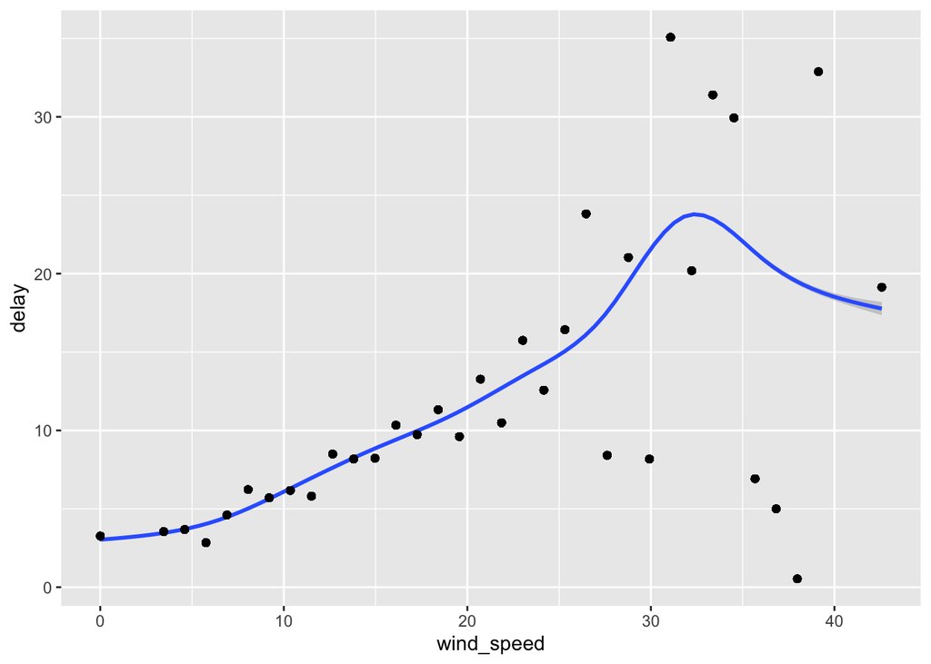

```r
  ggplot(data=wind_delay) +
    geom_smooth(mapping=aes(x=wind_speed,y=delay)) +
    geom_point(mapping=aes(x=wind_speed,y=delay))
```

As wind speed increases, delay increases.

### Exercise 5

What happened on June 13 2013? Display the spatial pattern of delays, and then use Google to cross-reference with the weather.

```r
flights
```

```
## # A tibble: 336,776 × 19
##     year month   day dep_time sched_dep_time dep_delay arr_time sched_arr_time
##    <int> <int> <int>    <int>          <int>     <dbl>    <int>          <int>
##  1  2013     1     1      517            515         2      830            819
##  2  2013     1     1      533            529         4      850            830
##  3  2013     1     1      542            540         2      923            850
##  4  2013     1     1      544            545        -1     1004           1022
##  5  2013     1     1      554            600        -6      812            837
##  6  2013     1     1      554            558        -4      740            728
##  7  2013     1     1      555            600        -5      913            854
##  8  2013     1     1      557            600        -3      709            723
##  9  2013     1     1      557            600        -3      838            846
## 10  2013     1     1      558            600        -2      753            745
## # … with 336,766 more rows, and 11 more variables: arr_delay <dbl>,
## #   carrier <chr>, flight <int>, tailnum <chr>, origin <chr>, dest <chr>,
## #   air_time <dbl>, distance <dbl>, hour <dbl>, minute <dbl>, time_hour <dttm>
```

```r
delays_by_dest_june13 <- flights %>%
  filter(year==2013) %>% #unnecessary since its only 2013 flights
  filter(month==6) %>%
  filter(day==13) %>%
  group_by(dest) %>%
  summarise(delay = mean(arr_delay,na.rm=T))

delays_by_dest_june13
```

```
## # A tibble: 89 × 2
##    dest  delay
##    <chr> <dbl>
##  1 ABQ    64
##  2 ACK     8
##  3 ALB   -19
##  4 ATL   109.
##  5 AUS    64.3
##  6 AVL    90
##  7 BDL    18.5
##  8 BGR   102
##  9 BHM   158
## 10 BNA    95.9
## # … with 79 more rows
```

```r
joined <- delays_by_dest_june13 %>%
  left_join(airports,c("dest"="faa"))

joined
```

```
## # A tibble: 89 × 9
##    dest  delay name                           lat    lon   alt    tz dst   tzone
##    <chr> <dbl> <chr>                        <dbl>  <dbl> <dbl> <dbl> <chr> <chr>
##  1 ABQ    64   Albuquerque International S…  35.0 -107.   5355    -7 A     Amer…
##  2 ACK     8   Nantucket Mem                 41.3  -70.1    48    -5 A     Amer…
##  3 ALB   -19   Albany Intl                   42.7  -73.8   285    -5 A     Amer…
##  4 ATL   109.  Hartsfield Jackson Atlanta …  33.6  -84.4  1026    -5 A     Amer…
##  5 AUS    64.3 Austin Bergstrom Intl         30.2  -97.7   542    -6 A     Amer…
##  6 AVL    90   Asheville Regional Airport    35.4  -82.5  2165    -5 A     Amer…
##  7 BDL    18.5 Bradley Intl                  41.9  -72.7   173    -5 A     Amer…
##  8 BGR   102   Bangor Intl                   44.8  -68.8   192    -5 A     Amer…
##  9 BHM   158   Birmingham Intl               33.6  -86.8   644    -6 A     Amer…
## 10 BNA    95.9 Nashville Intl                36.1  -86.7   599    -6 A     Amer…
## # … with 79 more rows
```

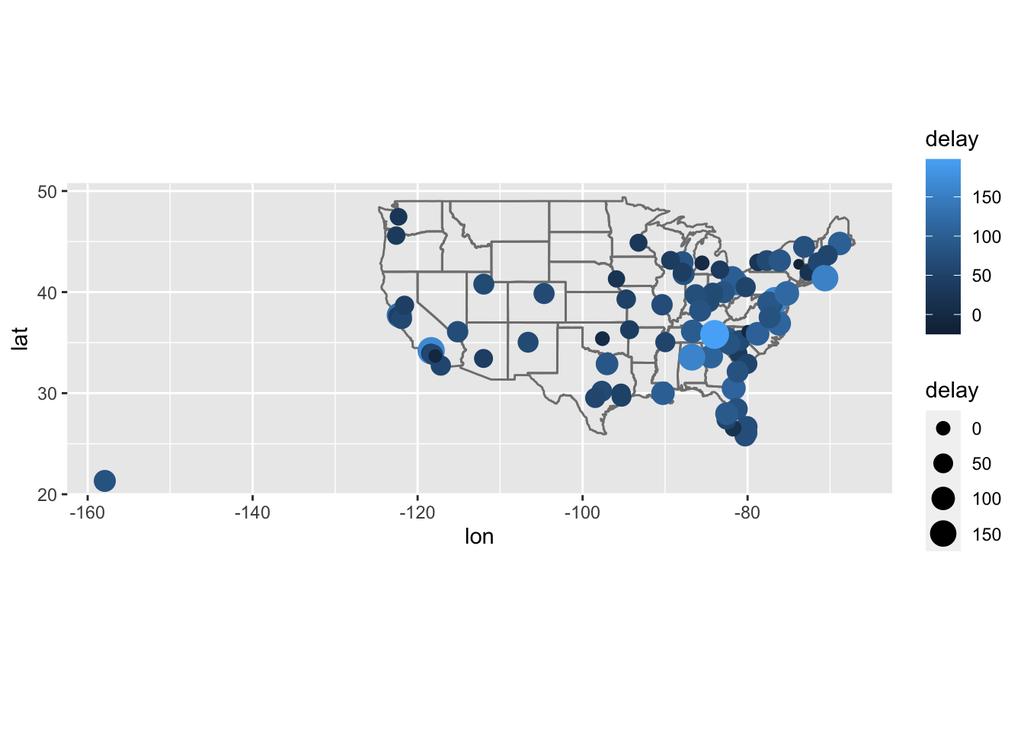

```r
joined %>%
  ggplot(aes(lon, lat,color=delay,size=delay)) +
    borders("state") +
    geom_point() +
    coord_quickmap()
```

here is the map of arrival delays at each destination airport on June 13th 2013. An internet search confirms that there were severe thunderstorms for my own area (Ohio) and many other areas on this day.

## 13.5.1 (1–5)

### Exercise 1

```r
flights %>%
  anti_join(planes, by = "tailnum") %>%
  count(tailnum, sort = T)
```

```
## # A tibble: 722 × 2
##    tailnum     n
##    <chr>   <int>
##  1 <NA>     2512
##  2 N725MQ    575
##  3 N722MQ    513
##  4 N723MQ    507
##  5 N713MQ    483
##  6 N735MQ    396
##  7 N0EGMQ    371
##  8 N534MQ    364
##  9 N542MQ    363
## 10 N531MQ    349
## # … with 712 more rows
```

```r
?planes
```

most tailnum in flights that doesnt have a match in planes starts with N, and ends with MQ or AA This associates with american airlines and envoy air. Looking at the planes data, this is stated: “Plane metadata for all plane tailnumbers found in the FAA aircraft registry. American Airways (AA) and Envoy Air (MQ) report fleet numbers rather than tail numbers so can’t be matched.”

### Exercise 2

Filter flights to only show flights with planes that have flown at least 100 flights.

```r
#planes

flights
```

```
## # A tibble: 336,776 × 19
##     year month   day dep_time sched_dep_time dep_delay arr_time sched_arr_time
##    <int> <int> <int>    <int>          <int>     <dbl>    <int>          <int>
##  1  2013     1     1      517            515         2      830            819
##  2  2013     1     1      533            529         4      850            830
##  3  2013     1     1      542            540         2      923            850
##  4  2013     1     1      544            545        -1     1004           1022
##  5  2013     1     1      554            600        -6      812            837
##  6  2013     1     1      554            558        -4      740            728
##  7  2013     1     1      555            600        -5      913            854
##  8  2013     1     1      557            600        -3      709            723
##  9  2013     1     1      557            600        -3      838            846
## 10  2013     1     1      558            600        -2      753            745
## # … with 336,766 more rows, and 11 more variables: arr_delay <dbl>,
## #   carrier <chr>, flight <int>, tailnum <chr>, origin <chr>, dest <chr>,
## #   air_time <dbl>, distance <dbl>, hour <dbl>, minute <dbl>, time_hour <dttm>
```

```r
#finding the planes that have flown over 100 flights (we need the flights that use theses planes)
planes_with_100_flights <- flights %>%
  filter(!is.na(tailnum)) %>% # get rid of tailnum NA's
  group_by(tailnum) %>%
  count() %>%
  filter(n>=100)

#the flights that use the above planes
flights %>%
  semi_join(planes_with_100_flights,by=c("tailnum"="tailnum"))
```

```
## # A tibble: 228,390 × 19
##     year month   day dep_time sched_dep_time dep_delay arr_time sched_arr_time
##    <int> <int> <int>    <int>          <int>     <dbl>    <int>          <int>
##  1  2013     1     1      517            515         2      830            819
##  2  2013     1     1      533            529         4      850            830
##  3  2013     1     1      544            545        -1     1004           1022
##  4  2013     1     1      554            558        -4      740            728
##  5  2013     1     1      555            600        -5      913            854
##  6  2013     1     1      557            600        -3      709            723
##  7  2013     1     1      557            600        -3      838            846
##  8  2013     1     1      558            600        -2      849            851
##  9  2013     1     1      558            600        -2      853            856
## 10  2013     1     1      558            600        -2      923            937
## # … with 228,380 more rows, and 11 more variables: arr_delay <dbl>,
## #   carrier <chr>, flight <int>, tailnum <chr>, origin <chr>, dest <chr>,
## #   air_time <dbl>, distance <dbl>, hour <dbl>, minute <dbl>, time_hour <dttm>
```

### Exercise 3

Combine fueleconomy::vehicles and fueleconomy::common to find only the records for the most common models.

```r
library(fueleconomy)
```

```r
common
```

```
## # A tibble: 347 × 4
##    make  model                n years
##    <chr> <chr>            <int> <int>
##  1 Acura Integra             42    16
##  2 Acura Legend              28    10
##  3 Acura MDX 4WD             12    12
##  4 Acura NSX                 28    14
##  5 Acura TSX                 27    11
##  6 Audi  A4                  49    19
##  7 Audi  A4 Avant quattro    49    15
##  8 Audi  A4 quattro          66    19
##  9 Audi  A6                  20    19
## 10 Audi  A6 Avant quattro    12    12
## # … with 337 more rows
```

```r
vehicles
```

```
## # A tibble: 33,442 × 12
##       id make  model        year class trans drive   cyl displ fuel    hwy   cty
##    <dbl> <chr> <chr>       <dbl> <chr> <chr> <chr> <dbl> <dbl> <chr> <dbl> <dbl>
##  1 13309 Acura 2.2CL/3.0CL  1997 Subc… Auto… Fron…     4   2.2 Regu…    26    20
##  2 13310 Acura 2.2CL/3.0CL  1997 Subc… Manu… Fron…     4   2.2 Regu…    28    22
##  3 13311 Acura 2.2CL/3.0CL  1997 Subc… Auto… Fron…     6   3   Regu…    26    18
##  4 14038 Acura 2.3CL/3.0CL  1998 Subc… Auto… Fron…     4   2.3 Regu…    27    19
##  5 14039 Acura 2.3CL/3.0CL  1998 Subc… Manu… Fron…     4   2.3 Regu…    29    21
##  6 14040 Acura 2.3CL/3.0CL  1998 Subc… Auto… Fron…     6   3   Regu…    26    17
##  7 14834 Acura 2.3CL/3.0CL  1999 Subc… Auto… Fron…     4   2.3 Regu…    27    20
##  8 14835 Acura 2.3CL/3.0CL  1999 Subc… Manu… Fron…     4   2.3 Regu…    29    21
##  9 14836 Acura 2.3CL/3.0CL  1999 Subc… Auto… Fron…     6   3   Regu…    26    17
## 10 11789 Acura 2.5TL        1995 Comp… Auto… Fron…     5   2.5 Prem…    23    18
## # … with 33,432 more rows
```

```r
vehicles %>%
  semi_join(common,by=c("make"="make","model"="model"))
```

```
## # A tibble: 14,531 × 12
##       id make  model    year class     trans drive   cyl displ fuel    hwy   cty
##    <dbl> <chr> <chr>   <dbl> <chr>     <chr> <chr> <dbl> <dbl> <chr> <dbl> <dbl>
##  1  1833 Acura Integra  1986 Subcompa… Auto… Fron…     4   1.6 Regu…    28    22
##  2  1834 Acura Integra  1986 Subcompa… Manu… Fron…     4   1.6 Regu…    28    23
##  3  3037 Acura Integra  1987 Subcompa… Auto… Fron…     4   1.6 Regu…    28    22
##  4  3038 Acura Integra  1987 Subcompa… Manu… Fron…     4   1.6 Regu…    28    23
##  5  4183 Acura Integra  1988 Subcompa… Auto… Fron…     4   1.6 Regu…    27    22
##  6  4184 Acura Integra  1988 Subcompa… Manu… Fron…     4   1.6 Regu…    28    23
##  7  5303 Acura Integra  1989 Subcompa… Auto… Fron…     4   1.6 Regu…    27    22
##  8  5304 Acura Integra  1989 Subcompa… Manu… Fron…     4   1.6 Regu…    28    23
##  9  6442 Acura Integra  1990 Subcompa… Auto… Fron…     4   1.8 Regu…    24    20
## 10  6443 Acura Integra  1990 Subcompa… Manu… Fron…     4   1.8 Regu…    26    21
## # … with 14,521 more rows
```

### Exercise 4

Find the 48 hours (over the course of the whole year) that have the worst delays. Cross-reference it with the weather data. Can you see any patterns?

```r
delay_by_hour <- flights %>%
  group_by(hour) %>%
  summarise(mean_delay=mean(dep_delay,na.rm=T))

delay_by_hour
```

```
## # A tibble: 20 × 2
##     hour mean_delay
##    <dbl>      <dbl>
##  1     1    NaN
##  2     5      0.688
##  3     6      1.64
##  4     7      1.91
##  5     8      4.13
##  6     9      4.58
##  7    10      6.50
##  8    11      7.19
##  9    12      8.61
## 10    13     11.4
## 11    14     13.8
## 12    15     16.9
## 13    16     18.8
## 14    17     21.1
## 15    18     21.1
## 16    19     24.8
## 17    20     24.3
## 18    21     24.2
## 19    22     18.8
## 20    23     14.0
```

### Exercise 5

What does anti_join(flights, airports, by = c(“dest” = “faa”)) tell you? What does anti_join(airports, flights, by = c(“faa” = “dest”)) tell you?

The first expression removes all the flights with destinations in the airports dataset. leaving only the flights that dont have an faa code in airports. perhaps international?

the second line removes all the airports that were destinations in the flights dataset. leaving only the airports with an faa code not flown to by airports in nyc in 2013

### Exercise 6

You might expect that there’s an implicit relationship between plane and airline, because each plane is flown by a single airline. Confirm or reject this hypothesis using the tools you’ve learned above.

```r
flights %>%
  group_by(tailnum,carrier) %>%
  summarise(count=n()) %>%
  ungroup() %>% ungroup() %>%
  group_by(tailnum) %>%
  summarise(count=n(),carrier) %>%
  filter(count>1) %>%
  ungroup() %>%
  left_join(airlines,by=c("carrier"="carrier"))
```

```
## # A tibble: 41 × 4
##    tailnum count carrier name
##    <chr>   <int> <chr>   <chr>
##  1 N146PQ      2 9E      Endeavor Air Inc.
##  2 N146PQ      2 EV      ExpressJet Airlines Inc.
##  3 N153PQ      2 9E      Endeavor Air Inc.
##  4 N153PQ      2 EV      ExpressJet Airlines Inc.
##  5 N176PQ      2 9E      Endeavor Air Inc.
##  6 N176PQ      2 EV      ExpressJet Airlines Inc.
##  7 N181PQ      2 9E      Endeavor Air Inc.
##  8 N181PQ      2 EV      ExpressJet Airlines Inc.
##  9 N197PQ      2 9E      Endeavor Air Inc.
## 10 N197PQ      2 EV      ExpressJet Airlines Inc.
## # … with 31 more rows
```

The hypthesis is rejected. Flights can be flown by multiple carriers through buying and selling in the same year. (I am writing quick bc my work was deleted for exercise 5 and 6 :( )

before my work was deleted, I found that tailnum N146PQ was sold in 2013 around months 2-4 from 9E to EV (also shown above without a date)

# Additional Exercise

```r
load(url(
"https://www.stat.osu.edu/~vqv/4194/data/masters2011-untidy.rda"
))
```

```r
round1T <- round1 %>%
  pivot_longer(`1`:`18`,names_to="hole",values_to="score") %>%
  mutate(round=1.0,hole=as.integer(hole))
round1T
```

```
## # A tibble: 1,782 × 4
##    player          hole score round
##    <chr>          <int> <int> <dbl>
##  1 Aaron Baddeley     1     4     1
##  2 Aaron Baddeley     2     4     1
##  3 Aaron Baddeley     3     4     1
##  4 Aaron Baddeley     4     3     1
##  5 Aaron Baddeley     5     4     1
##  6 Aaron Baddeley     6     3     1
##  7 Aaron Baddeley     7     4     1
##  8 Aaron Baddeley     8     4     1
##  9 Aaron Baddeley     9     4     1
## 10 Aaron Baddeley    10     5     1
## # … with 1,772 more rows
```

```r
round2T <- round2 %>%
  pivot_longer(`1`:`18`,names_to="hole",values_to="score") %>%
  mutate(hole=as.integer(hole),round=2.0)
round2T
```

```
## # A tibble: 1,782 × 4
##    player          hole score round
##    <chr>          <int> <int> <dbl>
##  1 Aaron Baddeley     1     4     2
##  2 Aaron Baddeley     2     4     2
##  3 Aaron Baddeley     3     4     2
##  4 Aaron Baddeley     4     3     2
##  5 Aaron Baddeley     5     4     2
##  6 Aaron Baddeley     6     3     2
##  7 Aaron Baddeley     7     4     2
##  8 Aaron Baddeley     8     5     2
##  9 Aaron Baddeley     9     4     2
## 10 Aaron Baddeley    10     3     2
## # … with 1,772 more rows
```

```r
round3T <- round3 %>%
  pivot_longer(`1`:`18`,names_to="hole",values_to="score") %>%
  mutate(hole=as.integer(hole),round=3.0)
round3T
```

```
## # A tibble: 882 × 4
##    player          hole score round
##    <chr>          <int> <int> <dbl>
##  1 Aaron Baddeley     1     4     3
##  2 Aaron Baddeley     2     5     3
##  3 Aaron Baddeley     3     3     3
##  4 Aaron Baddeley     4     3     3
##  5 Aaron Baddeley     5     3     3
##  6 Aaron Baddeley     6     2     3
##  7 Aaron Baddeley     7     5     3
##  8 Aaron Baddeley     8     5     3
##  9 Aaron Baddeley     9     5     3
## 10 Aaron Baddeley    10     5     3
## # … with 872 more rows
```

```r
round4T <- round4 %>%
  pivot_longer(`1`:`18`,names_to="hole",values_to="score") %>%
  mutate(hole=as.integer(hole),round=4.0)
round4T
```

```
## # A tibble: 882 × 4
##    player          hole score round
##    <chr>          <int> <int> <dbl>
##  1 Aaron Baddeley     1     5     4
##  2 Aaron Baddeley     2     4     4
##  3 Aaron Baddeley     3     4     4
##  4 Aaron Baddeley     4     3     4
##  5 Aaron Baddeley     5     4     4
##  6 Aaron Baddeley     6     3     4
##  7 Aaron Baddeley     7     4     4
##  8 Aaron Baddeley     8     6     4
##  9 Aaron Baddeley     9     4     4
## 10 Aaron Baddeley    10     4     4
## # … with 872 more rows
```

```r
#alternative to what was in lecture
rounds <- list(round1T,round2T,round3T,round4T)
all_rounds <- bind_rows(rounds)
all_rounds
```

```
## # A tibble: 5,328 × 4
##    player          hole score round
##    <chr>          <int> <int> <dbl>
##  1 Aaron Baddeley     1     4     1
##  2 Aaron Baddeley     2     4     1
##  3 Aaron Baddeley     3     4     1
##  4 Aaron Baddeley     4     3     1
##  5 Aaron Baddeley     5     4     1
##  6 Aaron Baddeley     6     3     1
##  7 Aaron Baddeley     7     4     1
##  8 Aaron Baddeley     8     4     1
##  9 Aaron Baddeley     9     4     1
## 10 Aaron Baddeley    10     5     1
## # … with 5,318 more rows
```

```r
winner <- leaderboard %>%
  filter(!position=="CUT") %>%
  filter(position==1)
winner
```

```
## # A tibble: 1 × 3
##   player           country      position
##   <chr>            <chr>        <fct>
## 1 Charl Schwartzel South Africa 1
```

```r
#install.packages("ggrepel")
library(ggrepel)
```

```r
with_par <- all_rounds %>%
  left_join(course,by="hole") %>%
  mutate(par_score=score-par) %>%
  group_by(player) %>%
  arrange(player,round,hole) %>%
  mutate(trueScore = cumsum(par_score)) %>%
  select(player,round,hole,trueScore,par_score,everything())
with_par
```

```
## # A tibble: 5,328 × 8
## # Groups:   player [99]
##    player         round  hole trueScore par_score score yards   par
##    <chr>          <dbl> <int>     <int>     <int> <int> <int> <int>
##  1 Aaron Baddeley     1     1         0         0     4   445     4
##  2 Aaron Baddeley     1     2        -1        -1     4   575     5
##  3 Aaron Baddeley     1     3        -1         0     4   350     4
##  4 Aaron Baddeley     1     4        -1         0     3   240     3
##  5 Aaron Baddeley     1     5        -1         0     4   455     4
##  6 Aaron Baddeley     1     6        -1         0     3   180     3
##  7 Aaron Baddeley     1     7        -1         0     4   450     4
##  8 Aaron Baddeley     1     8        -2        -1     4   570     5
##  9 Aaron Baddeley     1     9        -2         0     4   460     4
## 10 Aaron Baddeley     1    10        -1         1     5   495     4
## # … with 5,318 more rows
```

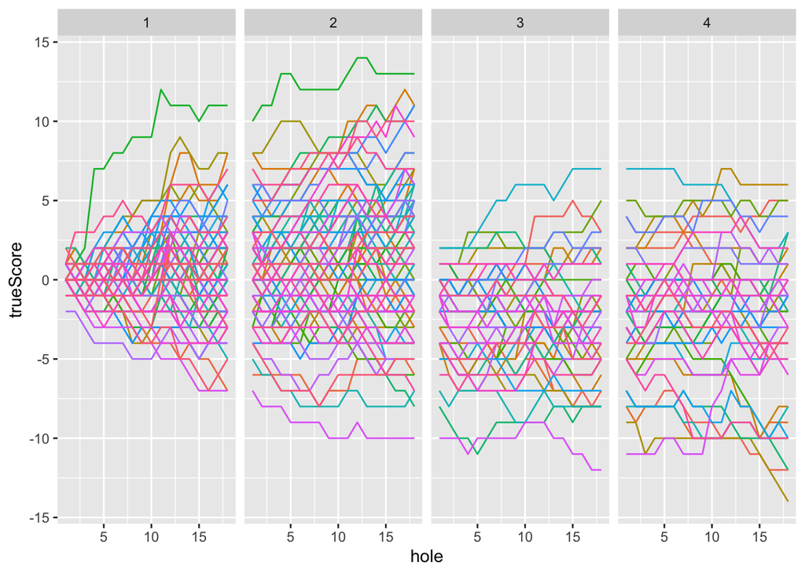

```r
ggplot(with_par,mapping=aes(x=hole,y=trueScore,group=player,color=player)) +
  geom_line(show.legend=F) +
  facet_grid(cols=vars(round))
```